# Psyc 471 project

Angela Liu

2023-12-04

### Motivation:

Education has always been a heated topic. All parents want their children to do better; however they provide “support” in different ways. Today’s child psychology has categorized parenting styles into four categories: permissive, authoritative, neglectful and authoritarian. Specifically, most parents in the United States are either authoritative or authoritarian. Not to assess which parenting style is definitely better than the other, this stimulation’s purpose is to see how students’ study behavior, specifically study time, would be impacted by their parenting styles given the grades received and provides some insights into what could be observed in real-world experiments.

### Introduction:

In this experiment, we aim to explore the intricate relationship between parenting styles and the academic behaviors of high school students, particularly focusing on how these styles influence students’ adjustment of study time for assignments. The core of our research questions revolves around two key aspects: Firstly, the impact of parenting style on the adjustments students make to their study time prior to assignments, and secondly, how this impact, in conjunction with the time adjustment, affects students’ aspirational grades for subsequent assignments. My hypothesis is that since students with authoritarian parents are taught to obey their parents’ rules, they are less likely to have independent thinking on how much they should study, thus adjusting their study time less than the authoritative students. In this experiment design, we will stimulate a high school course with 3 assignments: first assignment weighing 20% of the overall grade, the midterm weighing 30%, and the final weighing 50%.

### Data Generation:

To stimulate the experiment, we will first write a function, `generate_student_data()`, to generate a data frame of student data containing information on parenting style (binary variable), overall grade aspiration for all three assignments combined, and first assignment’s aspirational grade, study time, and actual grade.

The overall aspirational grade, first aspiration grade and first actual grade would follow a uniform distribution of $X \sim \mathrm{Uniform}(50, 100)$. And the first study time would follows a uniform distribution of $X \sim \mathrm{Uniform}(5, 100)$. The uniform distribution would generate random data without introducing any bias or assumption about the distribution of these attributes in the real world.

```r
# Function to generate a data frame of student data
generate_student_data <- function(n_students) {
  # Create a data frame with random values for each student's attributes
  data.frame(
    student_id = 1:n_students,
    parenting_style = sample(c("Authoritative", "Authoritarian"), n_students, replace = TRUE),
    overall_grade_aspiration = runif(n_students, 50, 100),
    first_aspirational_grade = runif(n_students, 50, 100),
    first_study_time = runif(n_students, 5, 100),
    first_actual_grade = runif(n_students, 50, 100)
  )
}

# Generate data for a specified number of students
n_students <- 100
students <- generate_student_data(n_students) # Generate the student data
head(students)
```

```
##   student_id parenting_style overall_grade_aspiration first_aspirational_grade
## 1          1   Authoritative                 83.74727                 70.05366
## 2          2   Authoritative                 56.07366                 83.57364
## 3          3   Authoritative                 85.34123                 73.10748
## 4          4   Authoritarian                 62.40196                 68.03138
## 5          5   Authoritative                 62.92598                 93.95492
## 6          6   Authoritarian                 91.36974                 55.37275
##   first_study_time first_actual_grade
## 1         25.57476           82.49799
## 2         22.49504           69.20306
## 3         70.68366           65.14399
## 4         60.77422           65.86094
## 5         87.90710           60.09000
## 6         48.88522           85.88472
```

```r
# Define fixed learning rates for different parenting styles
learning_rate_authoritative <- 0.5
learning_rate_authoritarian <- 0.2
```

### Part 1:

First write two functions to calculate adjusted study time and aspirational grade for the next assignment based on the previous assignment. Specifically, in the `calculate_study_time()` function, I will incorporate the RW model.

```r
# Function to calculate the adjusted study time for the next assignment
# In this function, I want to incorporate the RW model
calculate_study_time <- function(style, current_time, weight, aspirational_grade, actual_grade, alpha, beta) {
  prediction_error <- aspirational_grade - actual_grade

  # Determine the learning rate based on the parenting style
  learning_rate <- ifelse(style == "Authoritative", alpha, beta)

  # Calculate the adjustment in study time based on the learning rate and prediction error
  delta <- learning_rate * prediction_error

  # Update the study time for the next assignment
  new_time <- current_time + weight * delta

  # Ensure that the calculated study time is not negative
  return(max(new_time, 0))
}
```

```r
# Function to calculate the aspirational grade for the next assignment
calculate_aspirational_grade <- function(current_aspiration, time_adjustment, actual_grade, overall_aspiration) {
  # Adjust the aspirational grade based on the time adjustment and the difference between actual and overall aspiration
  new_aspiration <- current_aspiration + time_adjustment + (actual_grade - overall_aspiration)

  # Ensure that the aspirational grade is within the range of 0 to 100
  return(min(max(new_aspiration, 0), 100))
}
```

Now we can stimulate the midterm study time and aspirational grade using the functions written previously.

```r
# Loop through each student to simulate study time and aspirational grade adjustments
for (i in 1:nrow(students)) {
  student <- students[i, ] # Extract data for the current student

  # Calculate the study time for the next assignment (midterm) using the function calculate_study_time
  midterm_study_time <- calculate_study_time(
    student$parenting_style,
    student$first_study_time,
    0.3, # Weight of the midterm assignment
    student$first_aspirational_grade,
    student$first_actual_grade,
    learning_rate_authoritative,
    learning_rate_authoritarian
  )

  # Calculate the aspirational grade for the midterm using the function calculate_aspirational_grade
  midterm_aspirational_grade <- calculate_aspirational_grade(
    student$first_aspirational_grade,
    midterm_study_time - student$first_study_time,
    student$first_actual_grade,
    student$overall_grade_aspiration
  )

  # Update the dataset
  students$midterm_study_time[i] <- midterm_study_time
  students$midterm_aspirational_grade[i] <- midterm_aspirational_grade
}

head(students)
```

```
##   student_id parenting_style overall_grade_aspiration first_aspirational_grade
## 1          1   Authoritative                 83.74727                 70.05366
## 2          2   Authoritative                 56.07366                 83.57364
## 3          3   Authoritative                 85.34123                 73.10748
## 4          4   Authoritarian                 62.40196                 68.03138
## 5          5   Authoritative                 62.92598                 93.95492
## 6          6   Authoritarian                 91.36974                 55.37275
##   first_study_time first_actual_grade midterm_study_time
## 1         25.57476           82.49799           23.70811
## 2         22.49504           69.20306           24.65062
## 3         70.68366           65.14399           71.87819
## 4         60.77422           65.86094           60.90444
## 5         87.90710           60.09000           92.98684
## 6         48.88522           85.88472           47.05450
##   midterm_aspirational_grade
## 1                   66.93773
## 2                   98.85862
## 3                   54.10477
## 4                   71.62059
## 5                   96.19868
## 6                   48.05702
```

Let’s observe whether there is a difference in change of study time for different parenting styles. First, let’s calculate the difference in change in study time for each student.

```r
students <- students %>%
  mutate(change_in_study_time = midterm_study_time - first_study_time)
```

Let’s calculate the difference between the first actual grade and first aspirational grade and see its relationship with change in study time.

```r
students <- students %>%
  mutate(first_grade_difference = first_aspirational_grade - first_actual_grade)
head(students)
```

```
##   student_id parenting_style overall_grade_aspiration first_aspirational_grade
## 1          1   Authoritative                 83.74727                 70.05366
## 2          2   Authoritative                 56.07366                 83.57364
## 3          3   Authoritative                 85.34123                 73.10748
## 4          4   Authoritarian                 62.40196                 68.03138
## 5          5   Authoritative                 62.92598                 93.95492
## 6          6   Authoritarian                 91.36974                 55.37275
##   first_study_time first_actual_grade midterm_study_time
## 1         25.57476           82.49799           23.70811
## 2         22.49504           69.20306           24.65062
## 3         70.68366           65.14399           71.87819
## 4         60.77422           65.86094           60.90444
## 5         87.90710           60.09000           92.98684
## 6         48.88522           85.88472           47.05450
##   midterm_aspirational_grade change_in_study_time first_grade_difference
## 1                   66.93773           -1.8666491             -12.444328
## 2                   98.85862            2.1555875              14.370583
## 3                   54.10477            1.1945231               7.963487
## 4                   71.62059            0.1302264               2.170440
## 5                   96.19868            5.0797386              33.864924
## 6                   48.05702           -1.8307186             -30.511977
```

Let’s use graphs to explore the relationship between `change_in_study_time` and `first_grade_difference` between two parenting styles – authoritative and authoritarian.

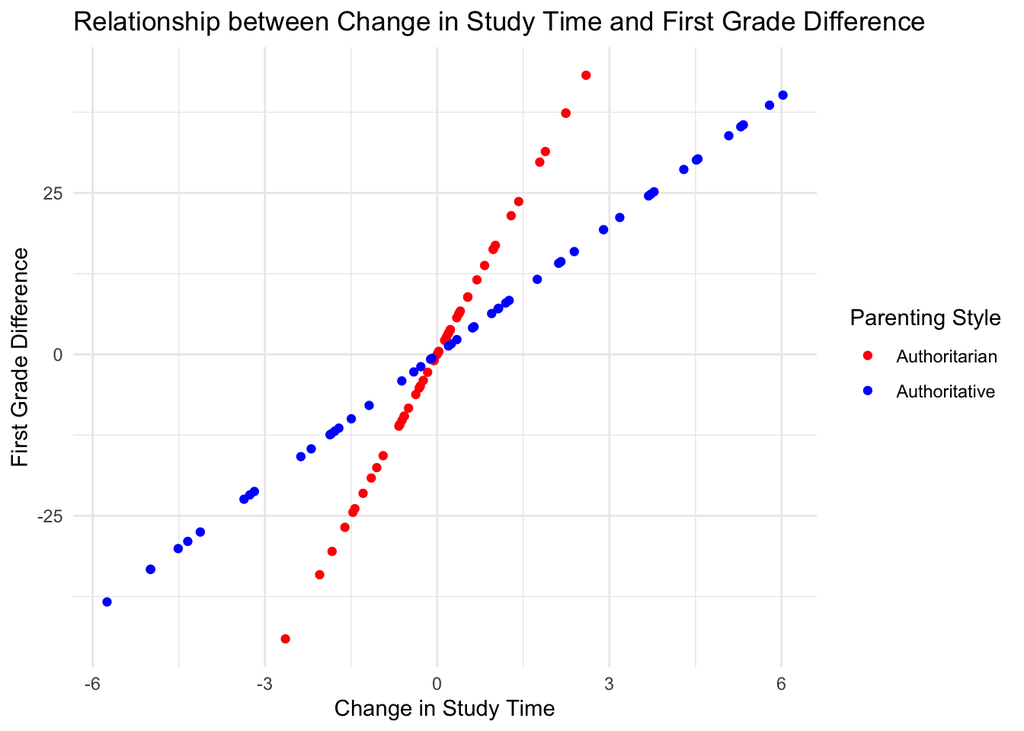

```r
library(ggplot2)

ggplot(students, aes(x = change_in_study_time, y = first_grade_difference, color = parenting_style)) +
  geom_point() +
  labs(title = "Relationship between Change in Study Time and First Grade Difference",
       x = "Change in Study Time",
       y = "First Grade Difference",
       color = "Parenting Style") +
  theme_minimal() +
  scale_color_manual(values = c("Authoritative" = "blue", "Authoritarian" = "red"))
```

Note that since we calculated the grade difference with `first_aspirational_grade - first_actual_grade`, a positive grade difference means the actual grade is lower than the aspirational, thus should increase the study time. From our graph, since both lines have positive slopes, it follows the intuitive sense. Examining closer at the range of the study time for the two groups, we see that Authoritative adjusts the study time more than Authoritarian given the same grade difference. This provides evidence to support our hypothesis that since Authoritative students have more freedom in their education, they will adjust their study time more according to the prediction error. Also, surprisingly, we see two perfectly straight lines for the dots, each representing an individual student.

Let’s generate midterm’s actual grade to apply the same functions to stimulate the final study time and aspirational grade.

```r
# Randomly generate midterm exam actual grade for students
students$midterm_actual_grade <- runif(nrow(students), 50, 100)
head(students)
```

```
##   student_id parenting_style overall_grade_aspiration first_aspirational_grade
## 1          1   Authoritative                 83.74727                 70.05366
## 2          2   Authoritative                 56.07366                 83.57364
## 3          3   Authoritative                 85.34123                 73.10748
## 4          4   Authoritarian                 62.40196                 68.03138
## 5          5   Authoritative                 62.92598                 93.95492
## 6          6   Authoritarian                 91.36974                 55.37275
##   first_study_time first_actual_grade midterm_study_time
## 1         25.57476           82.49799           23.70811
## 2         22.49504           69.20306           24.65062
## 3         70.68366           65.14399           71.87819
## 4         60.77422           65.86094           60.90444
## 5         87.90710           60.09000           92.98684
## 6         48.88522           85.88472           47.05450
##   midterm_aspirational_grade change_in_study_time first_grade_difference
## 1                   66.93773           -1.8666491             -12.444328
## 2                   98.85862            2.1555875              14.370583
## 3                   54.10477            1.1945231               7.963487
## 4                   71.62059            0.1302264               2.170440
## 5                   96.19868            5.0797386              33.864924
## 6                   48.05702           -1.8307186             -30.511977
##   midterm_actual_grade
## 1             89.98165
## 2             72.17496
## 3             63.38233
## 4             51.61634
## 5             86.34297
## 6             86.14433
```

```r
# Continue the simulation for the final exam for each student
for (i in 1:nrow(students)) {
  student <- students[i, ] # Extract data for the current student

  # Calculate study time for the final exam
  # The final exam has a higher weight thus its impact on study time is more significant
  final_study_time <- calculate_study_time(
    student$parenting_style,
    student$midterm_study_time,
    0.5, # Weight of the final exam
    student$midterm_aspirational_grade, # Use the aspirational grade from the midterm
    student$midterm_actual_grade,
    learning_rate_authoritative,
    learning_rate_authoritarian
  )

  # Calculate aspirational grade for the final exam
  final_aspirational_grade <- calculate_aspirational_grade(
    student$midterm_aspirational_grade, # Use the aspirational grade from the midterm
    final_study_time - student$midterm_study_time, # Time adjustment since the midterm
    student$midterm_actual_grade,
    student$overall_grade_aspiration
  )

  # Update the dataset
  students$final_study_time[i] <- final_study_time
  students$final_aspirational_grade[i] <- final_aspirational_grade
}
head(students)
```

```
##   student_id parenting_style overall_grade_aspiration first_aspirational_grade
## 1          1   Authoritative                 83.74727                 70.05366
## 2          2   Authoritative                 56.07366                 83.57364
## 3          3   Authoritative                 85.34123                 73.10748
## 4          4   Authoritarian                 62.40196                 68.03138
## 5          5   Authoritative                 62.92598                 93.95492
## 6          6   Authoritarian                 91.36974                 55.37275
##   first_study_time first_actual_grade midterm_study_time
## 1         25.57476           82.49799           23.70811
## 2         22.49504           69.20306           24.65062
## 3         70.68366           65.14399           71.87819
## 4         60.77422           65.86094           60.90444
## 5         87.90710           60.09000           92.98684
## 6         48.88522           85.88472           47.05450
##   midterm_aspirational_grade change_in_study_time first_grade_difference
## 1                   66.93773           -1.8666491             -12.444328
## 2                   98.85862            2.1555875              14.370583
## 3                   54.10477            1.1945231               7.963487
## 4                   71.62059            0.1302264               2.170440
## 5                   96.19868            5.0797386              33.864924
## 6                   48.05702           -1.8307186             -30.511977
##   midterm_actual_grade final_study_time final_aspirational_grade
## 1             89.98165         17.94713                 67.41113
## 2             72.17496         31.32154                100.00000
## 3             63.38233         69.55880                 29.82648
## 4             51.61634         62.90487                 62.83540
## 5             86.34297         95.45077                100.00000
## 6             86.14433         43.24577                 39.02288
```

Let’s make more graphs to gain other insights into this Part 1 stimulation

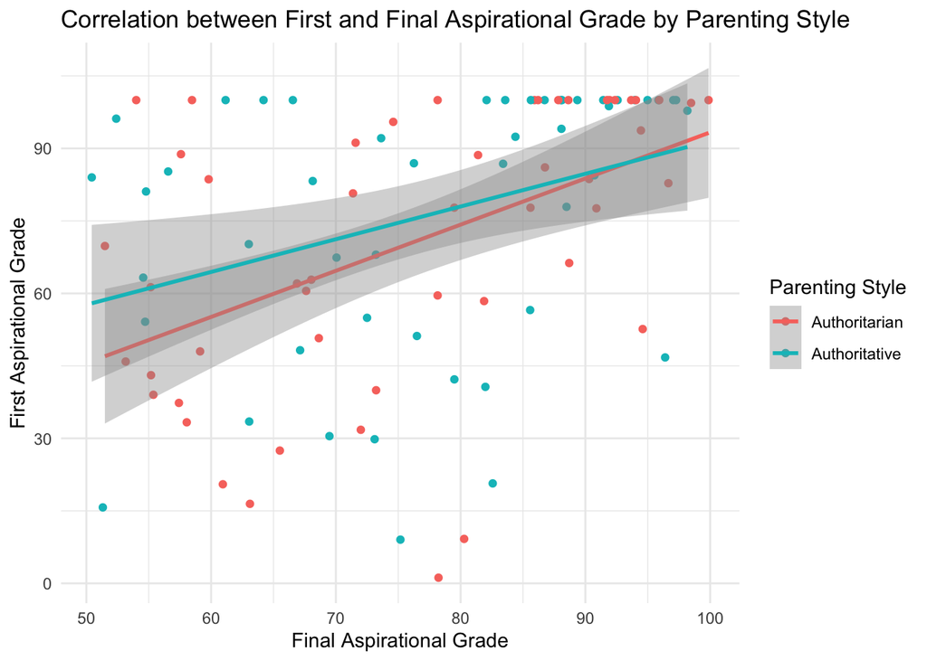

```r
ggplot(students, aes(x = first_aspirational_grade, y = final_aspirational_grade)) +
  geom_point(aes(color = parenting_style)) +
  geom_smooth(method = "lm", aes(group = parenting_style, color = parenting_style)) +
  labs(title = "Correlation between First and Final Aspirational Grade by Parenting Style",
       x = "Final Aspirational Grade",
       y = "First Aspirational Grade",
       color = "Parenting Style") +
  theme_minimal()
```

From this graph, we see that students in authoritarian group tend to have a lower final aspirational grade than first aspirational grade comparing to the authoritative group.

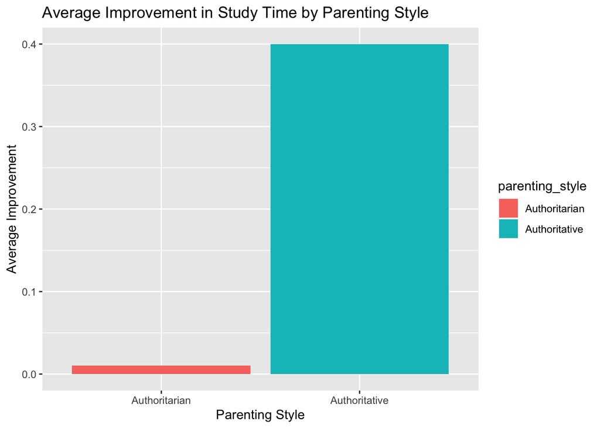

```r
students %>%
  group_by(parenting_style) %>%
  summarize(avg_improvement_study_time = mean(midterm_study_time - first_study_time)) %>%
  ggplot(aes(x = parenting_style, y = avg_improvement_study_time, fill = parenting_style)) +
  geom_bar(stat = "identity") +
  labs(title = "Average Improvement in Study Time by Parenting Style", x = "Parenting Style", y = "Average Improvement")
```

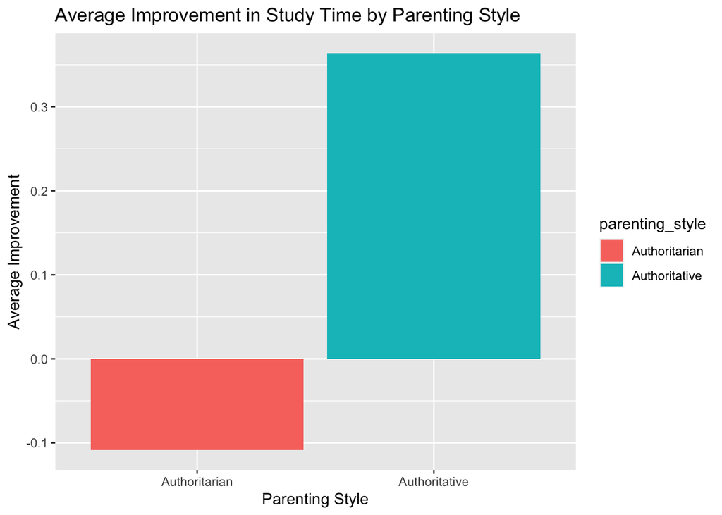

```r
students %>%
  group_by(parenting_style) %>%
  summarize(avg_improvement_study_time = mean(final_study_time - midterm_study_time)) %>%
  ggplot(aes(x = parenting_style, y = avg_improvement_study_time, fill = parenting_style)) +
  geom_bar(stat = "identity") +
  labs(title = "Average Improvement in Study Time by Parenting Style", x = "Parenting Style", y = "Average Improvement")
```

### Part 2: Dynamic learning rate

In part two, we will use dynamic learning rates to stimulate students’ study time for the final assignment.

```r
calculate_study_time_v2 <- function(style, current_time, weight, aspirational_grade, actual_grade) {
  prediction_error <- aspirational_grade - actual_grade

  # Draw learning rate from a normal distribution based on parenting style -- authoritative group with mean centered at 0.5 and authoritarian group centered at 0.2
  mean_lr <- ifelse(style == "Authoritative", 0.5, 0.2)
  learning_rate <- rnorm(1, mean = mean_lr, sd = 0.3) # An estimated standard deviation

  # Ensure the learning rate is non-negative
  learning_rate <- max(learning_rate, 0)

  delta <- learning_rate * prediction_error
  new_time <- current_time + weight * delta
  return(max(new_time, 0))
}

# Update the simulation loop
for (i in 1:nrow(students)) {
  student <- students[i, ]

  # Use the updated function with dynamic learning rates
  final_study_time_v2 <- calculate_study_time_v2(
    student$parenting_style,
    student$midterm_study_time,
    0.5,
    student$midterm_aspirational_grade,
    student$first_actual_grade
  )

  students$final_study_time_v2[i] <- final_study_time_v2
}

head(students)
```

```
##   student_id parenting_style overall_grade_aspiration first_aspirational_grade
## 1          1   Authoritative                 83.74727                 70.05366
## 2          2   Authoritative                 56.07366                 83.57364
## 3          3   Authoritative                 85.34123                 73.10748
## 4          4   Authoritarian                 62.40196                 68.03138
## 5          5   Authoritative                 62.92598                 93.95492
## 6          6   Authoritarian                 91.36974                 55.37275
##   first_study_time first_actual_grade midterm_study_time
## 1         25.57476           82.49799           23.70811
## 2         22.49504           69.20306           24.65062
## 3         70.68366           65.14399           71.87819
## 4         60.77422           65.86094           60.90444
## 5         87.90710           60.09000           92.98684
## 6         48.88522           85.88472           47.05450
##   midterm_aspirational_grade change_in_study_time first_grade_difference
```

[output cut: 20 more lines]

```r
students <- students %>%
  mutate(change_in_study_time_v2 = final_study_time_v2 - midterm_study_time,
         second_grade_difference = midterm_aspirational_grade - midterm_actual_grade)
head(students)
```

```
##   student_id parenting_style overall_grade_aspiration first_aspirational_grade
## 1          1   Authoritative                 83.74727                 70.05366
## 2          2   Authoritative                 56.07366                 83.57364
## 3          3   Authoritative                 85.34123                 73.10748
## 4          4   Authoritarian                 62.40196                 68.03138
## 5          5   Authoritative                 62.92598                 93.95492
## 6          6   Authoritarian                 91.36974                 55.37275
##   first_study_time first_actual_grade midterm_study_time
## 1         25.57476           82.49799           23.70811
## 2         22.49504           69.20306           24.65062
## 3         70.68366           65.14399           71.87819
## 4         60.77422           65.86094           60.90444
## 5         87.90710           60.09000           92.98684
## 6         48.88522           85.88472           47.05450
##   midterm_aspirational_grade change_in_study_time first_grade_difference
```

[output cut: 20 more lines]

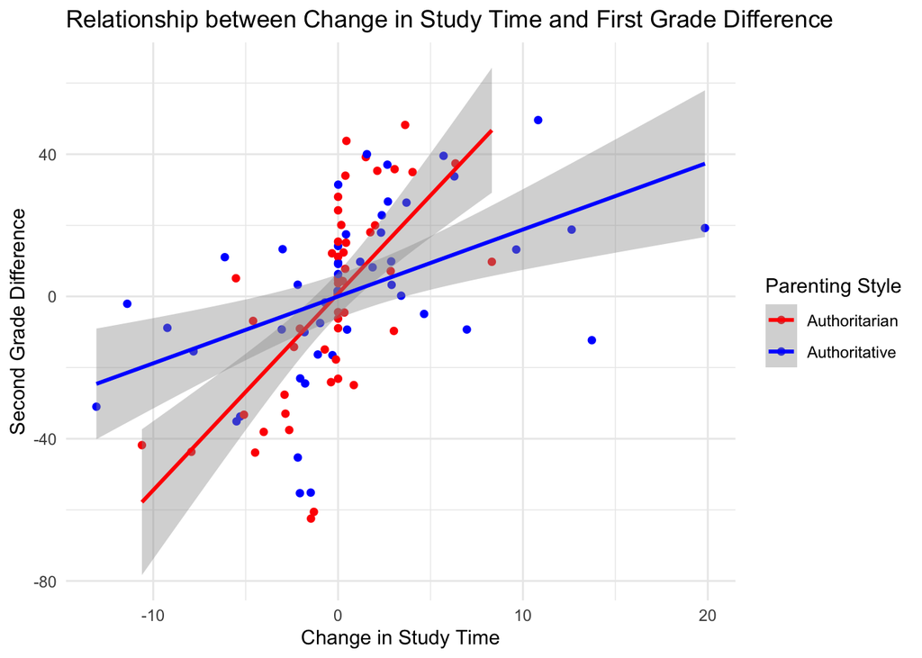

```r
ggplot(students, aes(x = change_in_study_time_v2, y = second_grade_difference, color = parenting_style)) +
  geom_point() +
  geom_smooth(method = "lm", aes(group = parenting_style, color = parenting_style)) +
  labs(title = "Relationship between Change in Study Time and First Grade Difference",
       x = "Change in Study Time",
       y = "Second Grade Difference",
       color = "Parenting Style") +
  theme_minimal() +
  scale_color_manual(values = c("Authoritative" = "blue", "Authoritarian" = "red"))
```

Unlike the first graph, with fixed learning rate comparing change in study time between the first assignment and midterm with the prediction error of the grade, with perfectly linear dots, the dots on this graph do not seem to follow a specific pattern. However, similarly, looking at the range of change in study time for the two groups, it is apparent that the authoritative group spans wider than the authoritarian group.

### Part 3: Bayes theorem

In part 3, we aim to use Bayes theorem to predict parenting style (Authoritative or Authoritarian) for each student based on their `midterm_study_time` and `first_grade_difference`. The logic is to first estimate the parameters (mean and standard deviation) for `first_grade_difference` and `midterm_study_time` for each parenting style, then calculate the likelihood of the observed data under each style, and finally apply Bayes’ theorem to predict the most likely parenting style for each student.

```r
# Function to estimate parameters for later use in the likelihood function
estimate_parameters <- function(data, style) { # Takes a dataset and a parenting style as inputs
  subset_data <- data[data$parenting_style == style, ] # Create a subset with row that style match the specified input style
  mean_midterm_study_time <- mean(as.numeric(subset_data$midterm_study_time))
  sd_midterm_study_time <- sd(as.numeric(subset_data$midterm_study_time))
  mean_first_grade_difference <- mean(as.numeric(subset_data$first_grade_difference))
  sd_first_grade_difference <- sd(as.numeric(subset_data$first_grade_difference))
  return(list(mean_midterm_study_time = mean_midterm_study_time, sd_midterm_study_time = sd_midterm_study_time,
              mean_first_grade_difference = mean_first_grade_difference, sd_first_grade_difference = sd_first_grade_difference))
  # Return a list that contains all calculated statistics
}
```

```r
# Estimating parameters for each parenting style
params_authoritative <- estimate_parameters(students, "Authoritative")
params_authoritarian <- estimate_parameters(students, "Authoritarian")
```

```r
# Likelihood Function: based on how typical the student's data is for the mean and standard deviation of `midterm_study_time` and `first_grade_difference` of each parenting style

calculate_likelihood <- function(midterm_study_time, first_grade_difference, style, params) {
  # Ensure inputs are numeric
  midterm_study_time <- as.numeric(midterm_study_time)
  first_grade_difference <- as.numeric(first_grade_difference)

  likelihood_study_time <- dnorm(midterm_study_time, mean = params$mean_midterm_study_time, sd = params$sd_midterm_study_time)
  likelihood_grade_difference <- dnorm(first_grade_difference, mean = params$mean_first_grade_difference, sd = params$sd_first_grade_difference)

  # Combined likelihood
  return(likelihood_study_time * likelihood_grade_difference)
}
```

```r
# Function to calculate the probability of a parenting style
predict_parenting_style <- function(midterm_study_time, first_grade_difference) {
  likelihood_authoritative <- calculate_likelihood(midterm_study_time, first_grade_difference, "Authoritative", params_authoritative)
  likelihood_authoritarian <- calculate_likelihood(midterm_study_time, first_grade_difference, "Authoritarian", params_authoritarian)

  # Bayes' theorem
  post_authoritative <- likelihood_authoritative * prior_authoritative /
    (likelihood_authoritative * prior_authoritative + likelihood_authoritarian * prior_authoritarian)
  post_authoritarian <- likelihood_authoritarian * prior_authoritarian /
    (likelihood_authoritative * prior_authoritative + likelihood_authoritarian * prior_authoritarian)

  if (post_authoritative > post_authoritarian) {
    return("Authoritative")
  } else {
    return("Authoritarian")
  }
}
```

```r
# Assuming equal probability for both parenting styles as a prior
prior_authoritative <- 0.5
prior_authoritarian <- 0.5

# Apply the prediction function to the dataset
students$predicted_parenting_style <- apply(students, 1, function(x) predict_parenting_style(x['midterm_study_time'], x['first_grade_difference']))

head(students)
```

```
##   student_id parenting_style overall_grade_aspiration first_aspirational_grade
## 1          1   Authoritative                 83.74727                 70.05366
## 2          2   Authoritative                 56.07366                 83.57364
## 3          3   Authoritative                 85.34123                 73.10748
## 4          4   Authoritarian                 62.40196                 68.03138
## 5          5   Authoritative                 62.92598                 93.95492
## 6          6   Authoritarian                 91.36974                 55.37275
##   first_study_time first_actual_grade midterm_study_time
## 1         25.57476           82.49799           23.70811
## 2         22.49504           69.20306           24.65062
## 3         70.68366           65.14399           71.87819
## 4         60.77422           65.86094           60.90444
## 5         87.90710           60.09000           92.98684
## 6         48.88522           85.88472           47.05450
##   midterm_aspirational_grade change_in_study_time first_grade_difference
```

[output cut: 27 more lines]

Let’s see how accurately Bayes theorem is able to predict the parenting style…

```r
# Calculate the number of correct predictions
correct_predictions <- sum(students$predicted_parenting_style == students$parenting_style)

# Calculate the total number of predictions
total_predictions <- nrow(students)

# Calculate the accuracy percentage
accuracy_percentage <- (correct_predictions / total_predictions) * 100

cat("Accuracy of predicting parenting styles:", accuracy_percentage, "%\n")
```

```
## Accuracy of predicting parenting styles: 54 %
```

### Conclusion:

However, please note that these are only the conclusions made based on stimulation results and they need to be experimented by real participants to be validated. Also, there are other limitations about this stimulation. For example, `overall_grade_aspiration` is randomly generated, thus having no relationship with the aspirational grade of any of the three assignments. However, in real life, the `overall_grade_aspiration` should have influence on the individual assignment’s grade expectation. Furthermore, the range for grade and study time and learning rates’ distribution are estimated/educated guess; there could be more variability in real life.